# Income Distribution by Country Compared to Scholastic Scores

#### Science

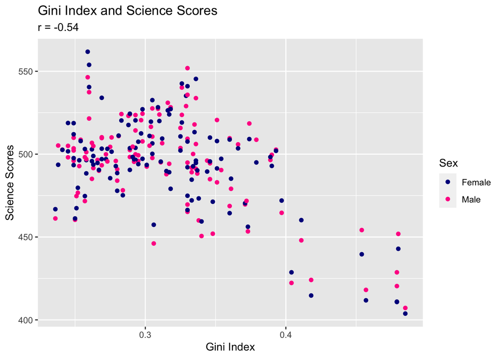

```r
ggplot(NAData,
       aes(x = Gini,
           y = science,
           color = Sex)) +
  geom_point() +
  labs(
    x = "Gini Index",
    y = "Science Scores",
    color = "Sex",
    title = "Gini Index and Science Scores",
    subtitle = "r = -0.54",
  ) +
  scale_color_manual(values = c("darkblue", "deeppink"))
```

#### Unemployed/Not In School

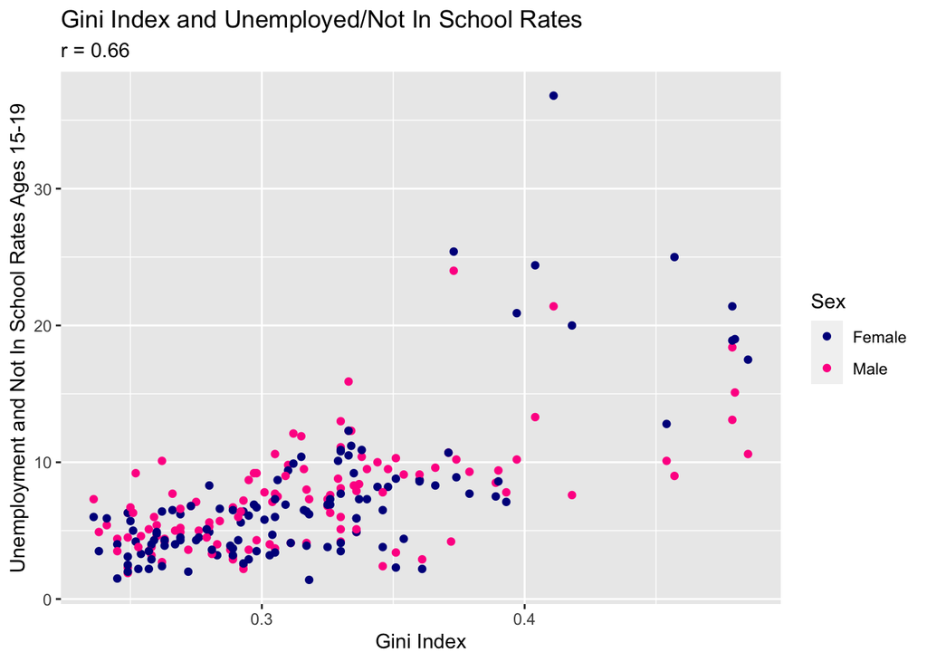

```r
ggplot(NAData,
       aes(x = Gini,
           y = unemployed_and_not_in_school_15_19,
           color = Sex)) +
  geom_point() +
  labs(
    x = "Gini Index",
    y = "Unemployment and Not In School Rates Ages 15-19",
    color = "Sex",
    title = "Gini Index and Unemployed/Not In School Rates",
    subtitle = "r = 0.66"
  ) +
  scale_color_manual(values = c("darkblue", "deeppink"))
```

# Model

## We will be creating multiple linear models to represent how the Gini Index affects different countries’ scholastic scores and unemployment/not in school percentages.

## Reading

```r
lmReading = lm(reading~Gini, data = NAData)
summary(lmReading)
```

```
Call:
lm(formula = reading ~ Gini, data = NAData)

Residuals:
    Min      1Q  Median      3Q     Max
-70.727 -21.143   2.914  19.726  62.404

Coefficients:
            Estimate Std. Error t value Pr(>|t|)
(Intercept)   561.02      10.11  55.496  < 2e-16 ***
Gini         -220.38      31.58  -6.978 2.98e-11 ***
---
Signif. codes:  0 '***' 0.001 '**' 0.01 '*' 0.05 '.' 0.1 ' ' 1

Residual standard error: 27.19 on 237 degrees of freedom
Multiple R-squared:  0.1704,    Adjusted R-squared:  0.1669
F-statistic: 48.69 on 1 and 237 DF,  p-value: 2.983e-11
```

## Math

```r
lmMath = lm(mathematics~Gini, data = NAData)
summary(lmMath)
```

```
Call:
lm(formula = mathematics ~ Gini, data = NAData)

Residuals:
    Min      1Q  Median      3Q     Max
-49.243 -14.110  -0.455  13.807  59.980

Coefficients:
            Estimate Std. Error t value Pr(>|t|)
(Intercept)  606.706      7.628   79.53   <2e-16 ***
Gini        -369.049     23.833  -15.48   <2e-16 ***
---
Signif. codes:  0 '***' 0.001 '**' 0.01 '*' 0.05 '.' 0.1 ' ' 1

Residual standard error: 20.52 on 237 degrees of freedom
Multiple R-squared:  0.5029,    Adjusted R-squared:  0.5008
F-statistic: 239.8 on 1 and 237 DF,  p-value: < 2.2e-16
```

## Science

```r
lmScience = lm(science~Gini, data = NAData)
summary(lmScience)
```

```
Call:
lm(formula = science ~ Gini, data = NAData)

Residuals:
    Min      1Q  Median      3Q     Max
-55.469 -14.417  -1.496  18.512  61.100

Coefficients:
            Estimate Std. Error t value Pr(>|t|)
(Intercept)  581.617      8.807   66.04   <2e-16 ***
Gini        -275.205     27.516  -10.00   <2e-16 ***
---
Signif. codes:  0 '***' 0.001 '**' 0.01 '*' 0.05 '.' 0.1 ' ' 1

Residual standard error: 23.69 on 237 degrees of freedom
Multiple R-squared:  0.2968,    Adjusted R-squared:  0.2938
F-statistic:   100 on 1 and 237 DF,  p-value: < 2.2e-16
```

## Unemployed/Not in School

```r
lmUnNot = lm(unemployed_and_not_in_school_15_19~Gini, data = NAData)
summary(lmUnNot)
```

```
Call:
lm(formula = unemployed_and_not_in_school_15_19 ~ Gini, data = NAData)

Residuals:
    Min      1Q  Median      3Q     Max
-7.6684 -1.8740 -0.2663  1.4210 24.1150

Coefficients:
            Estimate Std. Error t value Pr(>|t|)
(Intercept)  -10.467      1.328  -7.883 1.16e-13 ***
Gini          56.331      4.148  13.579  < 2e-16 ***
---
Signif. codes:  0 '***' 0.001 '**' 0.01 '*' 0.05 '.' 0.1 ' ' 1

Residual standard error: 3.571 on 237 degrees of freedom
Multiple R-squared:  0.4376,    Adjusted R-squared:  0.4352
F-statistic: 184.4 on 1 and 237 DF,  p-value: < 2.2e-16
```

# Communicate

This project analyzed how income inequality impacts a country’s students. Minors have very little choice about where they live and how they are educated, so it is their parents or their society’s responsibility to provide a good education. The Gini Index is a statistical measure of economic inequality. It measures how income or consumption is distributed among individuals or households within an economy. A score of 0 represents perfect income equality, while a score of 1 represents perfect income inequality. To see if there was a correlation between economic inequality and academic success we compared the Gini Index to a few academic indicators, namely: reading scores, math scores, science scores, and the rate of those unemployed and not in school in the 15-19 age group. We also included the comparison of scores between males and females as gender equality is also a good indicator of quality of life.

As shown in the scatter plots, there was a clear negative correlation between the Gini Index and the scores, and a clear positive correlation between the Gini Index and unemployment and out of school rates. From this, we can see that the more equal the income of a country is, the better the students and student-aged people do scholastically, and vocationally. This is especially evident in the Mathematics scores, shown by a correlation coefficient of -0.71, and the unemployed and not in school rate, shown by a correlation coefficient of 0.66. We created linear models for each of the scores as explained by the Gini Index and found by the p-values that Gini is an effective predictor for the scores. Just as with the correlation coefficients, the R-squared values for Mathematics scores and Unemployed and not in school rate showed that 50% and 44% of the variation in those variables can be explained by the Gini Index, respectively. The correlation coefficients and R-squared values are not nearly as strong for the Reading and Science scores, so it is a bit tougher to make conclusions there.